# Investigating Relationships between Demographics and Patient Outcomes in Californian Hospitals

Final Project: STAT-427/627 Spring 2024

Authors

Affiliations

Roland Abi

STAT-627

Elise Buellesbach

STAT-427

Amanda Concepcion

STAT-427

Spencer Grewe

STAT-627

Published

April 25, 2024

# 1 Executive Summary

In this paper, we dive into California’s medical system. Almost 40 million people call California home, as such understanding the efficacy of the California hospital system proves relevant. In this study, we seek to gain a better understanding of the factors that are associated with in-patient deaths in the CA hospital system. Increased staffing, according to the NIH, is associated with decreased levels of in-patient death. Based on this concept, we want to investigate other demographic and economic factors that may be impacting in-patient health.

To start, we completed a series of three regression analyses. In this analysis we want to know if we can predict in-patient deaths due to heart disease per thousand people. We start with a multiple linear regression that provides an unsatisfactory model with only two significant predictor variables. Next, we completed a LASSO regression which yielded insight into how the median income and age of the population impact deaths due to heart disease. The final regression model, a random forest model, reinforces the results from our other models. Through all three models, the number of cases of heart disease and the hospital rating are the most prevalent predictors. Age also continues to be a relevant variable with the population over the age of 55 most at risk. Based on weighting the importance of providing a detailed and robust model with the costs of adding additional variables and the risk of over fitting the data, we recommend using the random forest model.

Through this analysis, we gain insight into the California hospital system. We aim to build prediction models for both heart disease in-patient deaths and Health Professional Shortage Areas. HPSA is associated with higher mortality rates of in-patients and thus understanding outcomes in the hospital as well as staffing together provides a broader picture of California hospitals.

# 2 Data Overview

Data preparation code and documentation were omitted from this report, but can be found within the source code in the GitHub repository under `Data_Clean.qmd`. For this project, we used four data sets. The “hpsa.csv” file used Health Professional Shortage Areas (HPSA) data extracted from the California Department of Health Access. This data describes the geographic Health Professional Shortage Area (HPSA) federal designations for Primary Care, Mental Health, and Dental Health in counties within California. This original dataset contains 7,442 observations, and we extracted 10 of the 65 original variables. After identifying repeated counties, we removed repeat observations and selected only those that were unique, which led to a dataset with 587 unique observations. Also, two variables were collapsed: Health Professional Shortage Area (HPSA) population type was collapsed from two categories, migrant population and native Americans; rural status was collapsed from non rural, unknown, partially rural, and rural. This led us to have a total of 8 variables including metropolitan_indicator, designation_type, hpsa_status, hpsa_score, hpsa_designation_population, u_s_mexico_border_county_indicator, rural_status, and hpsa_population_type. We also collected data from the 2020 census and from the at the county level in California and the California State Association of Counties to integrate additional, up-to-date demographic variables into the analysis, such as race, poverty and median income, and proportion of the population within a given age bin.

Our “CA_datapile.xlsx” filed used data from a published dataset in the California’s Department of Health Care Access and Information. This dataset, with information from 2016 to 2021, looks at California Hospital Inpatient Mortality rates for 6 medical conditions and 5 procedures. It also contains demographic data for California counties which will let us ask research questions about how county-level demographics intersect patient outcome, specifically mortality. Specifically, it looks at various variables including sex, race, poverty, unemployment, and median income. To conduct regression analysis, a quantitative variable was needed. As a result, our team decided to take the Inpatient Mortality Indicators (IMI) data, extract cases and deaths due to heart attack in a hospital, and standardized these values by calculating the number of heart attack cases for every 1000 people and the number of heart attack deaths for every 1000 people. Strings were transformed to factor variables and we extracted features using regex. Each hospital had a categorical performance rating (worse, better, and as expected). The thousands of observations of hospital, cases, and demographic data was distilled to about a hundred entries. Every row is a unique combination of the cases and death rates per 1000 in hospitals in a specific county with a particular rating, as well as the additional hospital HPSA status and demographic information. Also, we removed hospital observational rows with missing entries in hospital quality, which is a factor that can lead to bias. To address missing data, we could have explored various alternative tactics: mean imputation and multivariate imputation, and future studies may address these concerns.

# 3 Classification Models

**Objective:** In the classification task, we seek to answer the question “Can health facilities within a county be designated as a Health Professional Shortage Area (HPSA) based on hpsa score, rural status, metropolitan indicator, designation type, HPSA designation population, HPSA population type and US-Mexico border indicator”.

## 3.1 Method 1: Logistic Regression

Two logistic regression models were employed to determine the predictors of hpsa status: A full model and a reduced model containing only predictors with p-values <0.05. We determined the best model by estimating the mean prediction error rate and using a 10-fold cross validation approach with a loss function. We determined the best model by selecting one with the lowest mean prediction error rate

```r
hpsa <- read_csv("Data/hpsa.csv")
```

```r
set.seed(123)

training_pct <- .60
Z <- sample(nrow(hpsa), training_pct*nrow(hpsa))

hpsa_train <- hpsa[Z, ]
hpsa_test <- hpsa[-Z, ]

#paste('Training set: ', nrow(hpsa_train))
#paste('Test set: ', nrow(hpsa_test))
```

```r
set.seed(123)
log_full <- glm(as.factor(hpsa_status) ~., data = hpsa_train,
                family = "binomial")
```

```r
#| include: false
set.seed(123)
log_reduced <- glm(as.factor(hpsa_status) ~ designation_type + hpsa_score +
                     rural_status + hpsa_population_type, data = hpsa_train,
                   family = "binomial")
```

```r
# Reduced model
# Predictions
preds_reduced <- predict(log_reduced, newdata = hpsa_test, type = "response")

# Convert to classification prediction
Yhat_reduced <-  ifelse(preds_reduced >= 0.5, "Withdrawn", "Designated")

# confusion matrix
confm_reduced <- table(Yhat_reduced, hpsa_test$hpsa_status)

# Correct classification prediction rate
accuracy_reduced <- sum(confm_reduced[1], confm_reduced[4])/sum(confm_reduced)

# test error rate
error_reduced <- mean(Yhat_reduced != hpsa_test$hpsa_status)
```

```r
# Full model
# Predictions
preds <- predict(log_full, newdata = hpsa_test, type = "response")

# Convert to classification prediction
Yhat <-  ifelse(preds >= 0.5, "Withdrawn", "Designated")

# confusion matrix
confm <- table(Yhat, hpsa_test$hpsa_status)

# Correct classification prediction rate
accuracy <- sum(confm[1], confm[4])/sum(confm)

# test error rate
error_full <- mean(Yhat != hpsa_test$hpsa_status)
```

```r
set.seed(123)

# Loss function
Lossfn <- function(Y, p) {
  mean(1 * (Y == 1 & p <= .50) | (1 * (Y == 0 & p > .50)),
       na.rm = TRUE)
}

# Convert response to numeric 0's and 1's
hpsa$Y <- as.numeric(as.factor(hpsa$hpsa_status)) - 1
```

```r
library(boot)
set.seed(123)

## Prediction error rate
# K = 10

# KFold Reduced
Kfold_reduced <- cv.glm(hpsa, log_reduced, cost = Lossfn, K=10)$delta


# Full Model
Kfold_full <- cv.glm(hpsa, log_full, cost = Lossfn, K=10)$delta
```

```r
anov <- anova(log_reduced, log_full, test = "Chisq")
```

```r
#| warning: false
#| tbl-cap: "Accuracy and Prediction Error Estimates"
#| label:   tbl-accuracy-preds

tibble(
  models = c("Reduced", "Full"),
  Accuracy = c(accuracy_reduced, accuracy),
  Error = c(error_reduced, error_full),
  Adjusted_MSEP = c(Kfold_reduced[2], Kfold_full[2])
) |>
  gt() |>
  tab_header(title = "Accuracy and Prediction Error Estimates Logistic regression models")
```

Accuracy and Prediction Error Estimates Logistic regression models

| models | Accuracy | Error | Adjusted_MSEP |
| --- | --- | --- | --- |
| Reduced | 0.812766 | 0.187234 | 0.1995639 |
| Full | 0.893617 | 0.106383 | 0.1497533 |

### 3.1.1 Summary of Logistic regression models

Giving the results obtained and from from the reduced and full logistic regression models and the results of model comparison we lack sufficient evidence (p = 2.446e-11) (SI Table 6) to conclude that logistic regression (reduced) model is better than the logistic regression (full) model. Consequently, we will recommend the full logistic regression model as the better model with predictors such as designation:HPSA_population, hpsa score rural_status:unknown and hpsa_population_type:native american among the significant predictors in determining hpsa status. The output of the full logistic regression model is found at (SI Table 4).

## 3.2 Method 2: Decision Tree

Two decision tree models were employed to determine the predictors of hpsa status: An unpruned model and a pruned model based on implementing a 10-fold cross validation and selecting the tree size with the lowest misclassification rate and nodes.

```r
#| echo: false
#| warning: false
set.seed(123)

tr <- tree(as.factor(hpsa_status) ~ ., data = train)
```

```r
#| echo: false
#| include: false

#plot(tr, type = "uniform")
#text(tr)
```

```r
#| echo: false
#| warning: false
#| include: false

set.seed(123)
cv <- cv.tree(tr, FUN = prune.misclass)
```

```r
#| echo: false
#| include: false

#plot(cv)
```

```r
#| echo: false
#| include: false

#plot(trp, type = "uniform")
#text(trp)
```

Accuracy and Prediction Error Estimates Tree models

Accuracy and Prediction Error Estimates Tree models

| models | Accuracy | Error |
| --- | --- | --- |
| Unpruned | 0.7951070 | 0.2048930 |
| Pruned | 0.7981651 | 0.2018349 |

### 3.2.1 Summary of Decision Tree models

“HPSA Score” and HPSA designation population were the dominant predictors in both the unpruned and pruned models. Overall, The pruned model had a mean prediction error rate of 0.2018349 which is a little lower than the unpruned tree which has an error rate of 0.204893. Meanwhile the accuracy of the pruned tree is 0.7981651 which represent a 0.3% increase in accuracy over the unpruned tree model with accuracy 0.795107 . We recommend the pruned tree (SI Figure 5 ) model.

## 3.3 Method 3: Boosting Method

Here we employed three models: An initial boosting model, a boosting model with shrinkage parameter and a cross validated (10-fold) boosting model with a shrinkage parameter.

```r
set.seed(123)
#| echo: false
boosth <- gbm(hpsa_status ~., data = train_b,
              n.trees = 3000, distribution = "Bernoulli")
```

```r
yhat <- predict(boosth, newdata = test_b, n.trees = 3000, type = "response")

# Convert to classification prediction
Yhat_class <-  ifelse(yhat >= 0.5, "Withdrawn", "Designated")
cfm_yhat <- table(Yhat_class, test_b$hpsa_status)

# prediction error rate and accuracy
yhat_error <- mean(Yhat_class != test_b$hpsa_status)
accuracy_yhat <- sum(cfm_yhat[1], cfm_yhat[4])/sum(cfm_yhat)
```

```r
set.seed(123)

#| echo: false
#adjust the shrinkage parameter

boosth_shrink <- gbm(hpsa_status ~ ., data = train_b,
              n.trees = 5000, shrinkage = 0.001, distribution = "Bernoulli")
```

```r
set.seed(123)

#| echo: false

boosth_cv <- gbm(hpsa_status ~ ., data = train_b,
              n.trees = 3000, shrinkage = 0.001,
              cv.folds = 10,
              distribution = "Bernoulli")
```

```r
#| tbl-cap: "Accuracy and Prediction Error Estimates of Boosting models"
tibble(
  Models = c("initial model", "boost_shrinkage", "boost_shrinkage_cv"),
  Accuracy = c(accuracy_yhat, accuracy_yhat2, accuracy_yhat3),
  Error = c(yhat_error, yhat2_error, yhat3_error)
) |>
  gt() |>
  tab_header(title = "Accuracy and Prediction Error Estimates of Boosting models")
```

Accuracy and Prediction Error Estimates of Boosting models

| Models | Accuracy | Error |
| --- | --- | --- |
| initial model | 0.877551 | 0.1224490 |
| boost_shrinkage | 0.877551 | 0.1224490 |
| boost_shrinkage_cv | 0.877551 | 0.3853211 |

# 4 Regression Models

## 4.1 Method 1. Multiple Linear and Ridge Regression

Here we are working on a basic multiple linear model with cross validation.

Question: Can mortality rate from heart disease per 1000 people be predicted from demographic conditions within counties in California?

To start, we will employ a series of multiple regressions to get a better understanding of the relationships at play and which variables are most useful in predicting the mortality rate from heart disease.

```r
library(tidyverse); theme_set(theme_bw())
reg_data_long <- read_csv(".\\Data\\reg_data_long.csv")
# head(reg_data_long)
reg_data_long$female_prop <- reg_data_long$FemalePop/reg_data_long$TotalPop
```

When I initially began building this model, I ran into issues in calculating the MSE because of a couple of NA values. To prevent this issue, I checked the data for NA values. Both PercFemale and PercUnder18yo have NA values and were thus removed from the full regression model.

```r
set.seed(123)

training_pct <- .8
Z <- sample(nrow(reg_data_long), floor(training_pct*nrow(reg_data_long)))

train <- reg_data_long[Z,]
# dim(train)
test <- reg_data_long[-Z,]
# dim(test)

test$County <- factor(test$County, levels = levels(train$County))
```

### 4.1.1 Full Model

```r
full_model <- lm(DeathsperThou ~ TotalPop + MalePop + FemalePop + MedianAge + MaleMedianAge + FemaleMedianAge + Under5yoPop + Under18yoPop + Pop21andOlder + Pop55andOlder + Pop60andOlder + Pop65andOlder + num_desig + amer_indian + black + hispanic + asian + multi_race + pac_island + white + poverty + labor_force + unemployed + median_income + TotalDeaths + TotalCases + prop_hpsa + nonwhite_prop + Rating + Deaths + unempl_prop + poverty_prop + prop55older + Cases + HospNumber + CasesperThou + female_prop , data = train)
```

```r
summary(full_model)
```

```
Call:
lm(formula = DeathsperThou ~ TotalPop + MalePop + FemalePop +
    MedianAge + MaleMedianAge + FemaleMedianAge + Under5yoPop +
    Under18yoPop + Pop21andOlder + Pop55andOlder + Pop60andOlder +
    Pop65andOlder + num_desig + amer_indian + black + hispanic +
    asian + multi_race + pac_island + white + poverty + labor_force +
    unemployed + median_income + TotalDeaths + TotalCases + prop_hpsa +
    nonwhite_prop + Rating + Deaths + unempl_prop + poverty_prop +
    prop55older + Cases + HospNumber + CasesperThou + female_prop,
    data = train)

Residuals:
     Min       1Q   Median       3Q      Max
-0.26702 -0.02710  0.00018  0.02693  0.38361

Coefficients: (1 not defined because of singularities)
                  Estimate Std. Error t value Pr(>|t|)
(Intercept)      1.476e+01  9.677e+00   1.525  0.13482
TotalPop        -5.931e-05  3.533e-05  -1.679  0.10079
MalePop         -3.238e-05  2.615e-05  -1.238  0.22266
FemalePop               NA         NA      NA       NA
MedianAge        3.873e-01  2.140e-01   1.810  0.07769 .
MaleMedianAge   -3.582e-01  1.234e-01  -2.904  0.00592 **
FemaleMedianAge -4.030e-01  1.508e-01  -2.672  0.01076 *
Under5yoPop     -4.857e-05  7.834e-05  -0.620  0.53872
Under18yoPop     8.693e-05  5.331e-05   1.631  0.11062
Pop21andOlder    9.340e-05  5.649e-05   1.653  0.10588
Pop55andOlder   -6.930e-05  6.245e-05  -1.110  0.27362
Pop60andOlder    1.896e-05  1.107e-04   0.171  0.86482
Pop65andOlder    4.339e-05  7.970e-05   0.544  0.58910
num_desig       -2.381e-03  2.080e-03  -1.145  0.25892
amer_indian      7.318e-06  3.708e-05   0.197  0.84453
black           -6.558e-06  9.342e-06  -0.702  0.48668
hispanic         8.807e-06  5.090e-06   1.730  0.09115 .
asian            4.462e-06  4.295e-06   1.039  0.30494
multi_race       6.853e-05  5.490e-05   1.248  0.21902
pac_island      -2.130e-05  6.064e-05  -0.351  0.72719
white            1.295e-06  4.764e-06   0.272  0.78711
poverty          5.334e-06  5.782e-06   0.922  0.36167
labor_force     -1.302e-05  8.837e-06  -1.474  0.14815
unemployed      -1.713e-05  1.891e-05  -0.906  0.37047
median_income    2.027e-05  1.331e-05   1.523  0.13534
TotalDeaths     -2.665e-04  9.168e-04  -0.291  0.77275
TotalCases      -5.199e-05  1.883e-05  -2.761  0.00858 **
prop_hpsa       -2.052e-02  2.950e-01  -0.070  0.94489
nonwhite_prop   -1.694e+00  1.696e+00  -0.999  0.32367
RatingBetter    -1.170e-01  1.015e-01  -1.153  0.25571
RatingWorse     -4.386e-02  1.007e-01  -0.436  0.66537
Deaths           2.238e-04  1.519e-04   1.473  0.14839
unempl_prop      4.769e+00  4.009e+00   1.190  0.24105
poverty_prop    -4.411e+00  6.737e+00  -0.655  0.51629
prop55older      2.768e+01  1.998e+01   1.386  0.17337
Cases           -3.037e-06  3.359e-06  -0.904  0.37129
HospNumber      -2.326e-04  1.308e-04  -1.778  0.08275 .
CasesperThou     3.264e-02  3.848e-03   8.482 1.46e-10 ***
female_prop     -1.737e+01  1.094e+01  -1.587  0.12011
---
Signif. codes:  0 '***' 0.001 '**' 0.01 '*' 0.05 '.' 0.1 ' ' 1

Residual standard error: 0.102 on 41 degrees of freedom
Multiple R-squared:  0.9655,    Adjusted R-squared:  0.9345
F-statistic: 31.06 on 37 and 41 DF,  p-value: < 2.2e-16
```

When looking at plots for this model, some concerns arise. For example, the plotting on the QQ-plot does not demonstrate a strong linear relationship. The edges of the plot deviate from the line suggesting that the model is not perfectly linear. Further, the scattered dots on the Leverage plot show several points on the line of Cook’s Distance signifying that they have overstated influence on the model. Further attentions is paid to these plots in the appendix.

```r
Yhat <- predict(full_model, newdata = test)

mse <- mean((test$DeathsperThou - Yhat)^2)
mse
```

```
[1] 0.07419842
```

The MSE is .0742. This is a low MSE in general. Next, we can see how a reduced model will work and then we will have a good point of comparison between the two models.

Here, I will take only the significant variables from the above model for the reduced model. This includes variables that are significant up to the p=.1 threshold This was chosen because so few variables are significant and I want to see what this model will yield. Then, we can remove more variables if the results warrant that action.

### 4.1.2 Reduced Model

```r
reduced_model <- lm(DeathsperThou ~ MedianAge + MaleMedianAge + FemaleMedianAge + hispanic + CasesperThou + TotalCases + HospNumber, data = train)
summary(reduced_model)
```

```
Call:
lm(formula = DeathsperThou ~ MedianAge + MaleMedianAge + FemaleMedianAge +
    hispanic + CasesperThou + TotalCases + HospNumber, data = train)

Residuals:
     Min       1Q   Median       3Q      Max
-0.40557 -0.05661 -0.01361  0.05143  0.56690

Coefficients:
                  Estimate Std. Error t value Pr(>|t|)
(Intercept)     -1.900e-01  1.517e-01  -1.252   0.2146
MedianAge        2.057e-01  1.394e-01   1.476   0.1443
MaleMedianAge   -1.208e-01  7.612e-02  -1.588   0.1168
FemaleMedianAge -8.090e-02  6.746e-02  -1.199   0.2344
hispanic         3.747e-08  8.951e-08   0.419   0.6768
CasesperThou     3.500e-02  1.482e-03  23.615   <2e-16 ***
TotalCases      -6.504e-07  1.326e-06  -0.491   0.6253
HospNumber      -1.122e-04  4.518e-05  -2.483   0.0154 *
---
Signif. codes:  0 '***' 0.001 '**' 0.01 '*' 0.05 '.' 0.1 ' ' 1

Residual standard error: 0.1192 on 71 degrees of freedom
Multiple R-squared:  0.9185,    Adjusted R-squared:  0.9104
F-statistic: 114.3 on 7 and 71 DF,  p-value: < 2.2e-16
```

This model yields a p-value of almost zero. It has an adjusted R^2 value of 0.9104 which is lower than the previous value from the full model of 0.9345. However, the decrease in the number of variables might be worth the slightly lower R^2 value.

```r
prediction_reduced <- predict(reduced_model, newdata = test)
mse_reduced <- mean((test$DeathsperThou - prediction_reduced)^2)
mse_reduced
```

```
[1] 0.05392615
```

However, we see a lower MSE at 0.0539 compared to 0.0742 from the full model. However, `hispanic`, `MedianAge`, `MaleMedianAge`, `FemaleMedianAge`, and `TotalCases` are no longer significant in this model.

```r
small_model <- lm(DeathsperThou ~ CasesperThou + HospNumber, data=train)
summary(small_model)
```

```
Call:
lm(formula = DeathsperThou ~ CasesperThou + HospNumber, data = train)

Residuals:
     Min       1Q   Median       3Q      Max
-0.42998 -0.05724 -0.00882  0.02736  0.69795

Coefficients:
               Estimate Std. Error t value Pr(>|t|)
(Intercept)   9.317e-03  1.768e-02   0.527  0.59983
CasesperThou  3.503e-02  1.451e-03  24.140  < 2e-16 ***
HospNumber   -1.230e-04  4.346e-05  -2.830  0.00595 **
---
Signif. codes:  0 '***' 0.001 '**' 0.01 '*' 0.05 '.' 0.1 ' ' 1

Residual standard error: 0.122 on 76 degrees of freedom
Multiple R-squared:  0.9087,    Adjusted R-squared:  0.9063
F-statistic: 378.1 on 2 and 76 DF,  p-value: < 2.2e-16
```

```r
prediction_small <- predict(small_model, newdata = test)
mse_small <- mean((test$DeathsperThou - prediction_reduced)^2)
mse_small
```

```
[1] 0.05392615
```

## 4.2 Method 2. LASSO Regression

### 4.2.1 Further Exploration of Multicollinearity

In social science and health data, multicollinearity has complex causes and is generally unavoidable. There are a few notable instances of collinearity within the regression predictors (SI Fig. 1). The non-white racial population proportion and the population proportion aged 55 years and older can be reliably predicted from the rest of the data, and certain pairs, such as poverty and unemployment, show evidence of an intuitively strong linear association.

While the cause of these co-correlations is outside of the scope of our analysis, we will now explore two additional regression methods, LASSO and random forest, which use shrinkage or bagging to reduce the variance in the prediction. Unlike simply removing predictors from the analysis, these two methods also allow for unbiased searches across all predictors to construct the best final model.

### 4.2.2 LASSO Regression

We employed a 10-fold LASSO regression to determine whether deaths per 1000 individuals due to heart disease can be predicted given demographic information, as well as information about the hospitals located within counties in California, controlling for heart disease cases and with a shrinkage penalty applied to address multicollinearity.

```r
model_train <- lm(DeathsperThou ~ Rating*CasesperThou + prop_hpsa + nonwhite_prop + median_income + unempl_prop
                                 + poverty_prop + Rating*prop55older + Rating*HospNumber,
                                 data = train)

X_model <- model.matrix(model_train)
X_model <- X_model[,-1]
y_train <- train$DeathsperThou

model_test <- lm(DeathsperThou ~ Rating*CasesperThou + prop_hpsa + nonwhite_prop + median_income + unempl_prop
                                 + poverty_prop + Rating*prop55older + Rating*HospNumber,
                                 data = test)

X_test <- model.matrix(model_test)
X_test <- X_test[,-1]
y_test <- test$DeathsperThou
```

```r
set.seed(123)
LASSO_reg <- cv.glmnet(X_model, y_train, alpha = 1)

# plot(LASSO_reg)
# coef(LASSO_reg)
mat <- cbind(coef(LASSO_reg), coef(LASSO_reg, s=LASSO_reg$lambda.min))
summ <- summary(mat)
n <- length(mat[,1])

data.frame(Min    = mat[,2],
           `1se`  = mat[,1]
           ) -> LASSO_estimates_SI
# LASSO_estimates_SI %>% knitr::kable(digits = 4)
```

```r
y_hat_1s <- predict(LASSO_reg, newx = X_test, type = "response", s = "lambda.1se")
y_hat_min <- predict(LASSO_reg, newx = X_test, type = "response", s = "lambda.min")

tibble(
  Model = c("lambda 1se", "lambda min"),
  `Prediction MSE` = c(mean((y_hat_1s - y_test)^2), mean((y_hat_min - y_test)^2)),
  `Number of Predictors` = c(1, 3)
) %>% knitr::kable()
```

Table 1: Overview and prediction performance of the LASSO models at two different L1 penalty strengths.

| Model | Prediction MSE | Number of Predictors |
| --- | --- | --- |
| lambda 1se | 0.0479827 | 1 |
| lambda min | 0.0150106 | 3 |

The prediction MSE for the lambda 1se model, which had only one significant predictor, is 0.04798, while the prediction MSE for the lambda min model with three predictors is 0.01501 (Table 1). The sole predictor in the first model was the heart disease case rate, and the difference in prediction error between the two models is a fairly large 68.72%. It is clear that these variables are lending predictive power to the model, but not enough to significantly outweigh a stronger L1 penalty imposed by LASSO.

## 4.3 Method 3. Regression Trees

### 4.3.1 Random Forest

```r
library(randomForest)
library(tidyverse); theme_set(theme_bw())
reg_data_long <- read_csv(".\\Data\\reg_data_long.csv")
# head(reg_data_long)
reg_data_long$Rating <- as.factor(reg_data_long$Rating)
reg_data_long$female_prop <- reg_data_long$FemalePop/reg_data_long$TotalPop

set.seed(123)
Z <- sample(1:nrow(reg_data_long), 0.8*nrow(reg_data_long), replace = FALSE)
train <- as.data.frame(reg_data_long[Z,])
test <- as.data.frame(reg_data_long[-Z,])
```

```r
p <- 9
RF <- OptimalTrees <- Yhat <- RMSEP <- vector(mode = "double", length = p)

set.seed(123)
for (k in 1:p) {
  RF <- randomForest(DeathsperThou ~ Rating*CasesperThou + prop_hpsa + nonwhite_prop + median_income + unempl_prop
                                 + poverty_prop + Rating*prop55older + Rating*HospNumber,
                                 data = train, mtry = k)
  OptimalTrees[k] <- which.min(RF$mse)
  RF <- randomForest(DeathsperThou ~ Rating*CasesperThou + prop_hpsa + nonwhite_prop + median_income + unempl_prop
                                 + poverty_prop + Rating*prop55older + Rating*HospNumber,
                                 data = train, mtry = k, ntree = OptimalTrees[k])
  Yhat <- predict(RF, newdata = test)
  RMSEP[k] <- sqrt(mean((Yhat - test$DeathsperThou)^2) )
}

# which.min(RMSEP)
# OptimalTrees[which.min(RMSEP)]
```

```r
set.seed(123)
model_RF <- randomForest(DeathsperThou ~ Rating*CasesperThou + prop_hpsa + nonwhite_prop + median_income + unempl_prop + poverty_prop + Rating*prop55older + Rating*HospNumber, data = train, mtry = 7, ntree = 398)
# model_RF
# plot(model_RF)

Y_hat <- predict(model_RF, newdata = test)
# mean((test$DeathsperThou-Y_hat)^2)

tibble(
  Metric = c("Number of Predictors", "Number of Trees", "Prediction MSE"),
  Value = list(which.min(RMSEP), OptimalTrees[which.min(RMSEP)], round(mean((test$DeathsperThou-Y_hat)^2), digits = 4))
) %>%  knitr::kable()
```

Table 2: Summary of cross-validated random forest results.

| Metric | Value |
| --- | --- |
| Number of Predictors | 7 |
| Number of Trees | 398 |
| Prediction MSE | 0.0299 |

We find that hospital rating and amount are significantly used predictors in the random forest, and likely reflect the quality and accessibility of care in different counties (SI Fig. 2). The effect of hospital rating and the number of hospitals far outweigh the effect of demographic factors, including the proportion of residents aged 55 years and older. In general, the random forest model performs with the second lowest prediction error of all regression models explored, and strikes a reasonable balance between bias and complexity in the number of predictors. We fail to find strong evidence of demographic factors, but these regression models illustrate that that hospital quality and number in counties in the state of California are associated with deaths due to heart disease when controlling for variation in the number of heart disease cases.

# 5 Ethical Analysis

Managing health-related data and models comes with a wide variety of serious ethical concerns. Understanding the risks of biased data or an inaccurate model is critical to safeguarding against these. As such, as we work on these models, we must keep in mind the privacy of patients, the quality of our data, and its ability to accurately represent the demographics of the whole population, and we must be mindful of the variables that are included or excluded.

1. Managing data: Collecting medical data is a delicate challenge. First and foremost, health data is personal and sensitive. It must be handled with the utmost respect and caution as it contains sensitive and personal information. The US legal system, through The Health Insurance Portability and Accountability Act of 1996 (HIPAA), protects sensitive patient information. However, to study the health system and understand the weaknesses and strengths of the current hospital system, we need data. As such, as data scientists, we must be sure to handle data in a careful manner that ensures that individual and identifiable information is not connected with the data used to build the model. Protecting privacy creates challenges in collecting the data and ensuring that the data is representative. ([NIH](https://www.ncbi.nlm.nih.gov/books/NBK9579/))
2. Biases and Representation: Medical data must be representative of the population it is measuring or we risk creating an inaccurate and harmful model. Inaccurate data can reinforce stereotypes leading to misdiagnosis and mistreatment. Medical data differs from other data sources because inaccuracies are often a matter of life and death. In this particular set of models, we need to be cautious about the demographics and our ability to generalize the results. For example, this data gives good insight into California’s hospital system, however, California is not representative of the nation. California’s median age (37.9) is the eleventh youngest in the nation and almost a year younger than the median age nationally (38.8). Further, California is more diverse than other states and has a larger population of immigrants (27%) compared to the rest of the country (12%) ([PPIC](https://www.ppic.org/publication/californias-population/)). Further, the median income in California is more than $15,000 greater than the national median income ([US Data](https://datausa.io/profile/geo/california?compare=united-states)). These are a couple of examples where California’s data does not represent the greater US. It is important to note these disparities and study how they might impact the data and prevent us from generalizing our data to other hospital systems. ([NIH](https://www.ncbi.nlm.nih.gov/pmc/articles/PMC8515002/))
3. Inclusion of Variables: In each model, we had to select which variables to include and which to exclude. For example, in the multiple linear regression models, `hispanic` was the only race variable that was significant in the full model and thus was included in the reduced model while others were not. This choice, even based on the data, is one that can impact the outcome. Transparency in which variables are included in the final models is critical to the reproducibility of the model and the preventing harmful biases.

Conversely, good data and strong models can serve as guidance to hospitals and be accountability measures. For example, the NIH has found a 10% increase in in-hospital mortality rates due to unsafe practices while increased staffing is correlated with a 12% decrease in deaths. Accurate data reporting can provide accountability for hospital practices. This gives community members insight into the medical system and the needed improvements in their locality.

Further, better public policy can stem from accurate reporting. For example, when considering our models, overlaying deaths and demographic information can highlight at-risk groups that need further support. We find in our LASSO analysis that patients over the age of 55 are at a higher risk of death. As such, policymakers know that they need to further focus on resources for this community. Continued monitoring of the death rate can demonstrate if policy changes yield a change in mortality rates. Good policy is based on good data and models.

# 6 Summary of Findings

# 7 Future Directions

The study reveals that the number of patients with heart disease, hospital ranking, and hospital number in a region are significant predictors of mortality rates. The classification model also reveals the importance of hpsa score, hpsa designation population, and metropolitan indicator in predicting health professional service area status. Despite the high accuracy of the models, they lack the necessary demographic characteristics for generalization due to low sample size and data collection methods. The researchers plan to explore further data transformation approaches and combine the predictions of both models into a stacking model to improve their performance. This could enhance the ability to determine mortality rates or hpsa status.

# 8 Appendix

## 8.1 Group Member Accomplishments

*Roland Abi*

Developed the research question for the classification, and found the data set for `california health professional shortage area` and cleaned and transformed the data. Completed logistic regression model (full and reduced), as well as cross validation approaches contributed to completing decision tree and boosting models, carried out 627 tasks for model selection and two wrote the classification section of the summary as well as future direction.

*Elise Buellesbach*

Found and proposed the original CA data set (`California Hospital Inpatient Mortality Rates and Quality Ratings`). Completed the linear regression models (both full and reduced). Wrote the executive summary, summary/conclusion, ethical analysis, and references.

*Amanda Concepcion*

I worked on developing two of the three classification models, specifically the decision tree and the boosting model. I worked on these models and developed graphics, found prediction error rates, and contributed to the cross-validation methods for the two models which Roland reviewed for errors. Also, I wrote the section elaborating on the data sources, challenges, and choices for cleaning the data.

*Spencer Grewe*

Organized report and repository. Acquired CA demographic data (`data4`). Contributed toward cleaning, tidying and joining data sets 1, 3, and 4 for the regression tasks. Made and summarized regression models 2 and 3, and carried out 627 tasks involving cross-validation, model selection, and survey of multicollinearity.

## 8.2 Statement of Data Availability

The source code, data, and full supporting information are available at the [shared repository](https://github.com/sbgrewe/STAT627-FinalProj), which will be made public on the date of the submission of this report. We declare that all authors equally own the contents of the repository.

## 8.3 Bibliography

- Asch, David A., Md Nazmul Islam, Natalie E. Sheils, Yong Chen, Jalpa A. Doshi, John Buresh, and Rachel M. Werner. 2021. “Patient and Hospital Factors Associated with Differences in Mortality Rates among Black and White US Medicare Beneficiaries Hospitalized with COVID-19 Infection.” JAMA Network Open 4 (6): e2112842. https://doi.org/10.1001/jamanetworkopen.2021.12842.
- California Open Data Portal. “California Hospital Inpatient Mortality Rates and Quality Ratings,” August 10, 2023. https://data.ca.gov/dataset/california-hospital-inpatient-mortality-rates-and-quality-ratings.
- California Open Data Portal. “Primary Care HPSAs,” March 28, 2024. https://data.ca.gov/dataset/health-professional-shortage-areas-in-california/resource/194e0874-7619-4d70-9198-47943ac17089.
- datausa.io. “California | Data USA,” n.d. https://datausa.io/profile/geo/california?compare=united-states.
- English, Mike, Paul Mwaniki, Thomas Julius, Mercy Chepkirui, David Gathara, Paul O. Ouma, Peter Cherutich, Emelda A. Okiro, and Robert W. Snow. 2018. “Hospital Mortality – a Neglected but Rich Source of Information Supporting the Transition to Higher Quality Health Systems in Low and Middle Income Countries.” BMC Medicine 16 (1). https://doi.org/10.1186/s12916-018-1024-8.
- Hoffmann JA, Attridge MM, Carroll MS, Simon NE, Beck AF, Alpern ER. Association of Youth Suicides and County-Level Mental Health Professional Shortage Areas in the US. JAMA Pediatr. 2023 Jan 1;177(1):71-80. doi: 10.1001/jamapediatrics.2022.4419. PMID: 36409484; PMCID: PMC9679958.
- “Hipaa Privacy Rule Booklet.” n.d. https://privacyruleandresearch.nih.gov/pdf/HIPAA_Privacy_Rule_Booklet.pdf.
- Johnson, Hans, Eric McGhee, and Marisol Cuellar Mejia. “California’s Population.” Public Policy Institute of California, January 2022. https://www.ppic.org/publication/californias-population/.
- Porcel-Gálvez, Ana María, Sergio Barrientos-Trigo, Eugenia Gil-García, Olivia Aguilera-Castillo, Antonio Juan Pérez-Fernández, and Elena Fernández-García. 2020. “Factors Associated with In-Hospital Mortality in Acute Care Hospital Settings: A Prospective Observational Study.” International Journal of Environmental Research and Public Health 17 (21): 7951. https://doi.org/10.3390/ijerph17217951.
- Nass, Sharyl J, Laura A Levit, and Lawrence O Gostin. “The Value and Importance of Health Information Privacy.” Nih.gov. National Academies Press (US), 2019. https://www.ncbi.nlm.nih.gov/books/NBK9579/.
- Norori, Natalia, Qiyang Hu, Florence Marcelle Aellen, Francesca Dalia Faraci, and Athina Tzovara. “Addressing Bias in Big Data and AI for Health Care: A Call for Open Science.” Patterns 2, no. 10 (October 8, 2021): 100347. https://doi.org/10.1016/j.patter.2021.100347.
- “Trends in Inpatient Hospital Deaths: National Hospital Discharge Survey, 2000–2010 .” 2019. CDC. 2019. https://www.cdc.gov/nchs/products/databriefs/db118.htm.

# 9 References

# 10 Supplemental Information

## 10.1 Appendix Graphics

*Linear Regression Model*

```r
library(tidyverse); theme_set(theme_bw())
reg_data_long <- read_csv(".\\Data\\reg_data_long.csv")
# head(reg_data_long)
reg_data_long$female_prop <- reg_data_long$FemalePop/reg_data_long$TotalPop

set.seed(123)

training_pct <- .8
Z <- sample(nrow(reg_data_long), floor(training_pct*nrow(reg_data_long)))

train <- reg_data_long[Z,]
# dim(train)
test <- reg_data_long[-Z,]
# dim(test)

test$County <- factor(test$County, levels = levels(train$County))

full_model <- lm(DeathsperThou ~ TotalPop + MalePop + FemalePop + MedianAge + MaleMedianAge + FemaleMedianAge + Under5yoPop + Under18yoPop + Pop21andOlder + Pop55andOlder + Pop60andOlder + Pop65andOlder + num_desig + amer_indian + black + hispanic + asian + multi_race + pac_island + white + poverty + labor_force + unemployed + median_income + TotalDeaths + TotalCases + prop_hpsa + nonwhite_prop + Rating + Deaths + unempl_prop + poverty_prop + prop55older + Cases + HospNumber + CasesperThou + female_prop , data = train)
```

NA Counts for Regression Data

```r
na_counts <- colSums(is.na(reg_data_long))
na_counts
```

```
         County        TotalPop         MalePop       FemalePop       MedianAge
              0               0               0               0               0
  MaleMedianAge FemaleMedianAge     Under5yoPop    Under18yoPop   Pop21andOlder
              0               0               0               0               0
  Pop55andOlder   Pop60andOlder   Pop65andOlder      PercFemale   PercUnder18yo
              0               0               0              12              12
      num_desig     amer_indian           black        hispanic           asian
              0               0               0               0               0
     multi_race      pac_island           white         poverty     labor_force
              0               0               0               0               0
     unemployed   median_income     TotalDeaths      TotalCases       prop_hpsa
              0               0               0               0               0
  nonwhite_prop          Rating          Deaths   DeathsperThou     unempl_prop
              0               0               0               0               0
   poverty_prop     prop55older           Cases      HospNumber    CasesperThou
              0               0               0               0               0
    female_prop
              0
```

Plotting Full Model

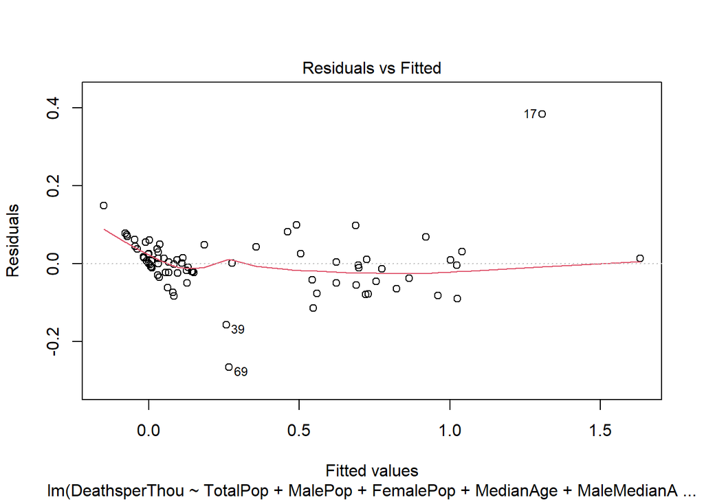

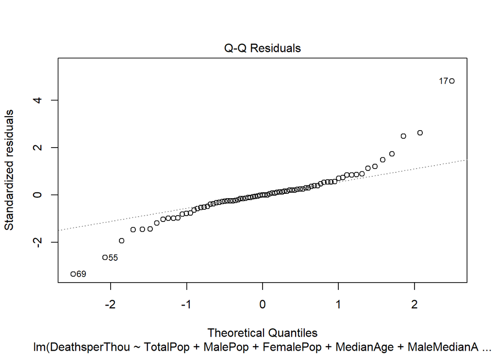

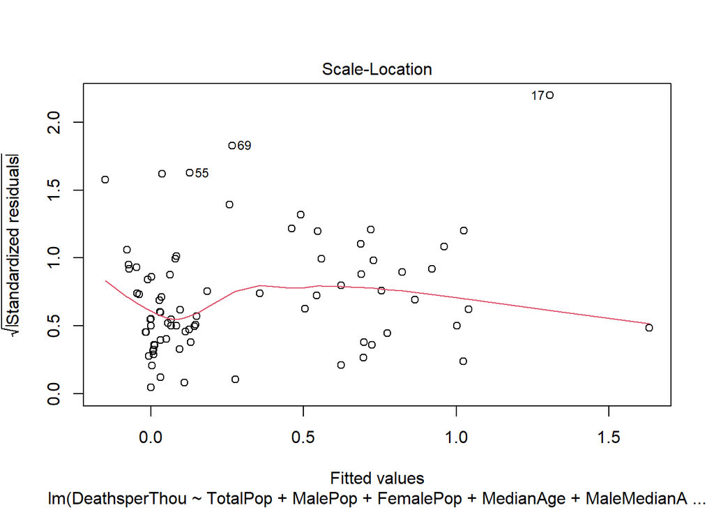

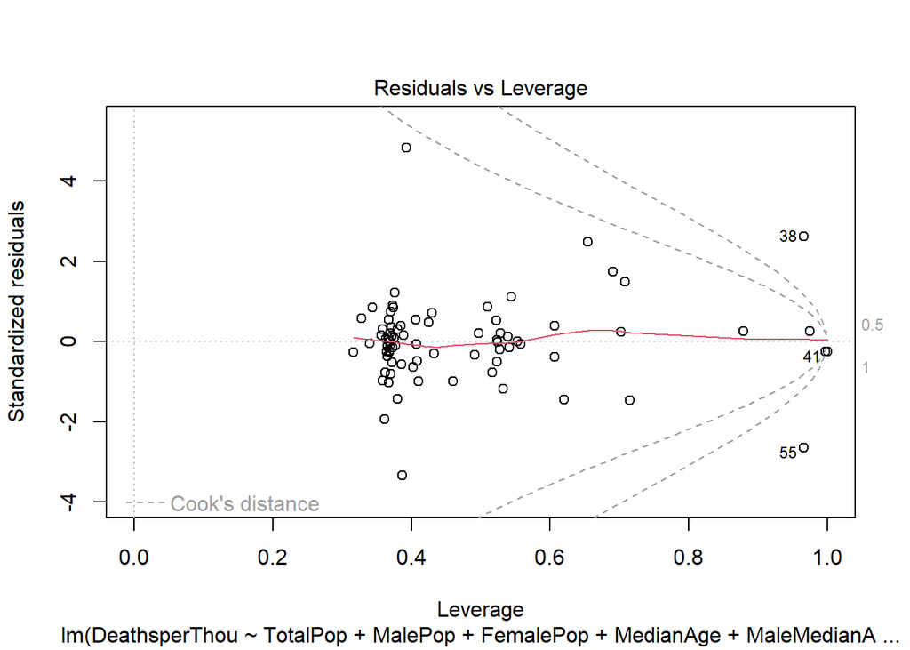

```r
plot(full_model)
```

These plots give some insight to the shape of the model. For example, the plotting on the QQ-plot does not demonstrate a strong linear relationship. The edges of the plot deviate from the line suggesting that the model is not perfectly linear. Further, the scattered dots on the Leverage plot show several points on the line of Cook’s Distance signifying that they have overstated influence on the model. With these concerns in mind, I want to investigate the linearity of the model further. Does a linear model make sense? To get a better understanding of the data, I created some basic plots to demonstrate the shape of the data and get an idea of if a linear model will make sense here ([source on code](https://www.statology.org/plot-multiple-linear-regression-in-r/))

Linear Fit of Variables

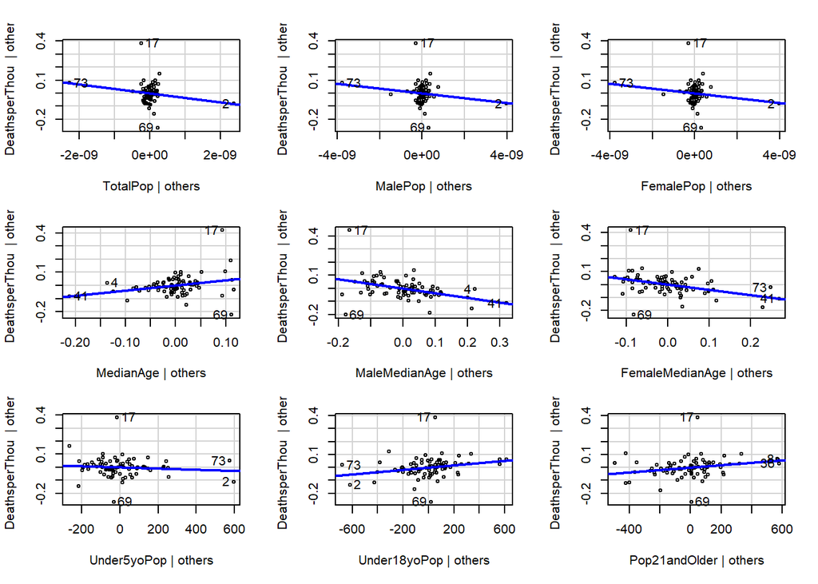

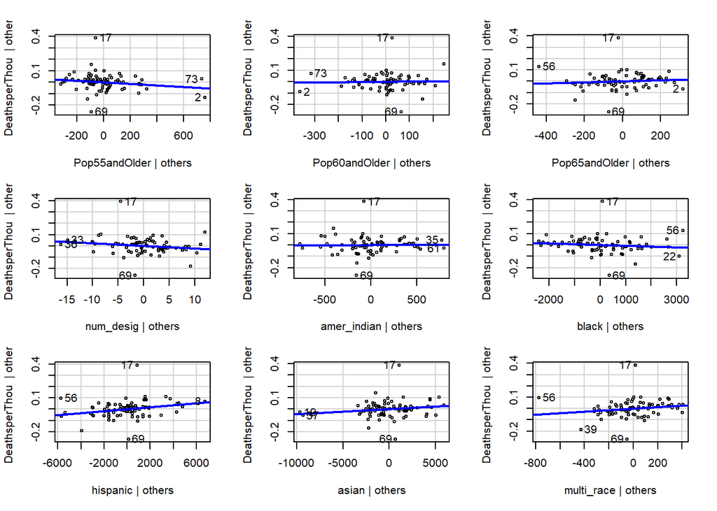

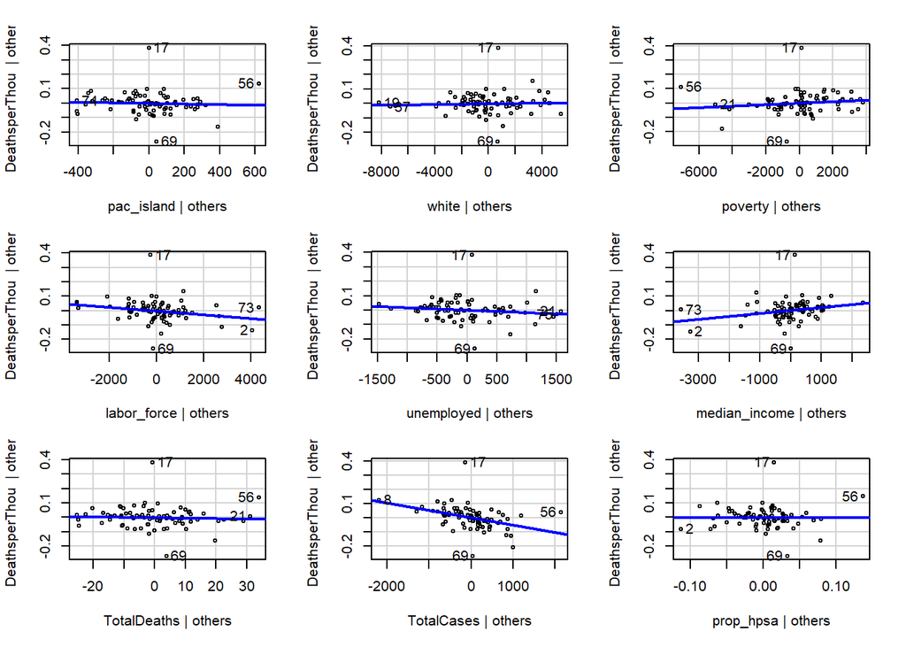

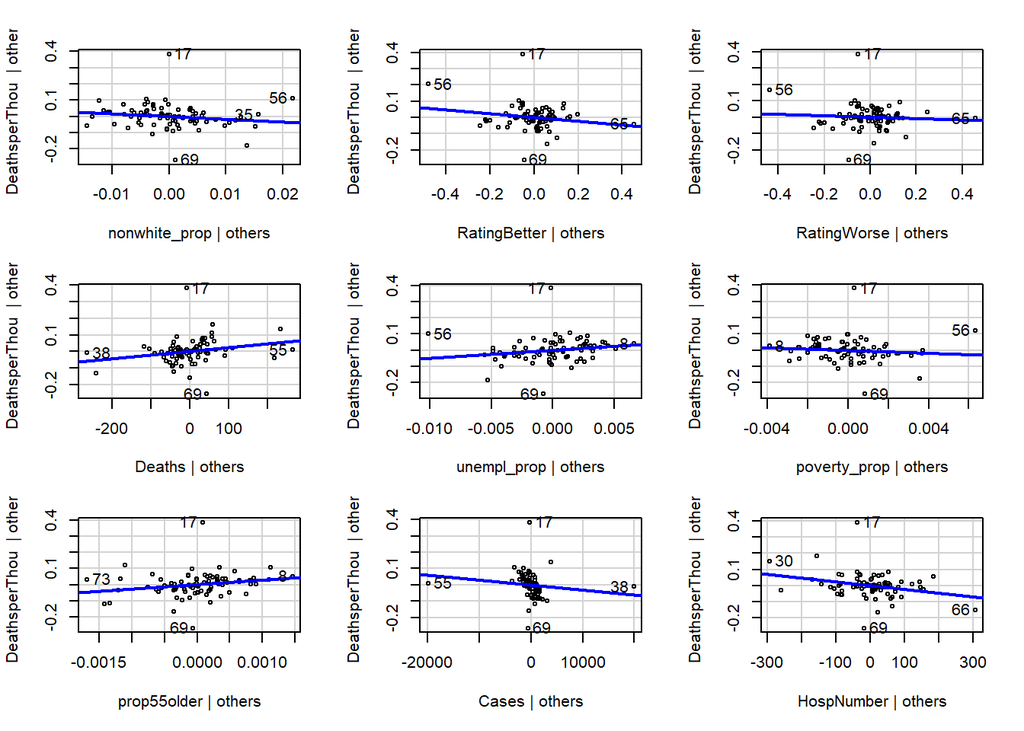

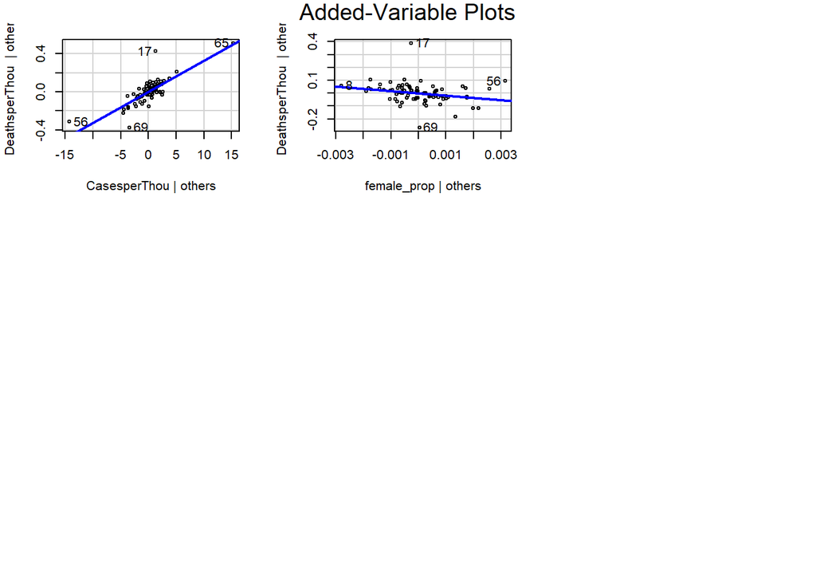

```r
library(car)
avPlots(full_model)
```

Here, we can see that some variables provide a better linear fit than others. For example, variables such as `MaleMedianAge` and `FemaleMedianAge` both are more or less scattered along the regression line. However, other variables such as `MalePop` and `FemalePop` do not fit the line well. Instead, the data is gathered in one spot and has almost no linear shape. These graphs give some reason for concern that the basic full model will not be the strongest. Not all of the variables are linear so a reduced model might be a better fit.

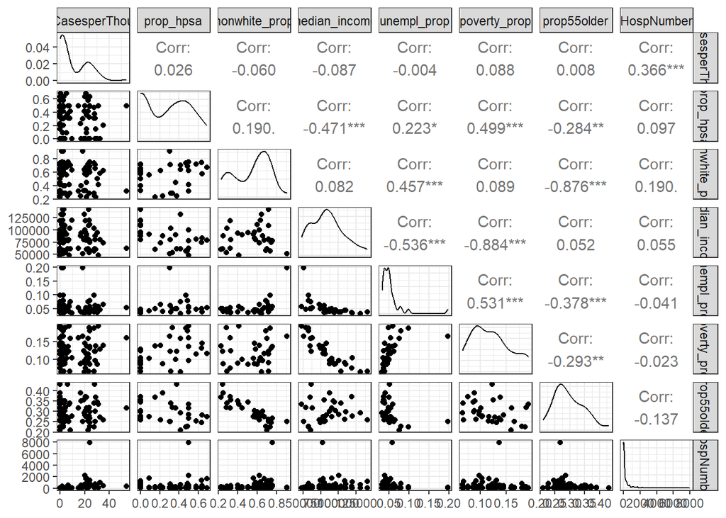

Figure 1: Pairs plot of predictors selected for regression.

```r
# reg_data_long[, c("CasesperThou", "prop_hpsa", "nonwhite_prop", "median_income", "unempl_prop","poverty_prop", "prop55older", "HospNumber")]

ggpairs(reg_data_long[, c("CasesperThou", "prop_hpsa", "nonwhite_prop", "median_income", "unempl_prop","poverty_prop", "prop55older", "HospNumber")])

# car::vif(lm(DeathsperThou ~ Rating + CasesperThou + prop_hpsa + nonwhite_prop + median_income + unempl_prop + poverty_prop + prop55older + HospNumber, data = train))
```

```r
LASSO_estimates_SI %>% knitr::kable(digits = 4)
```

Table 3: Coefficients and estimates obtained after LASSO regression at two different L1 penalty strengths.

|  | Min | X1se |
| --- | --- | --- |
| (Intercept) | -0.0936 | 0.0567 |
| RatingBetter | 0.0000 | 0.0000 |
| RatingWorse | 0.0000 | 0.0000 |
| CasesperThou | 0.0328 | 0.0271 |
| prop_hpsa | 0.0000 | 0.0000 |
| nonwhite_prop | 0.0000 | 0.0000 |
| median_income | 0.0000 | 0.0000 |
| unempl_prop | 0.0000 | 0.0000 |
| poverty_prop | 0.0000 | 0.0000 |
| prop55older | 0.4513 | 0.0000 |
| HospNumber | -0.0001 | 0.0000 |
| RatingBetter:CasesperThou | -0.0185 | 0.0000 |
| RatingWorse:CasesperThou | 0.0160 | 0.0000 |
| RatingBetter:prop55older | -0.0587 | 0.0000 |
| RatingWorse:prop55older | 0.0000 | 0.0000 |
| RatingBetter:HospNumber | 0.0000 | 0.0000 |
| RatingWorse:HospNumber | 0.0000 | 0.0000 |

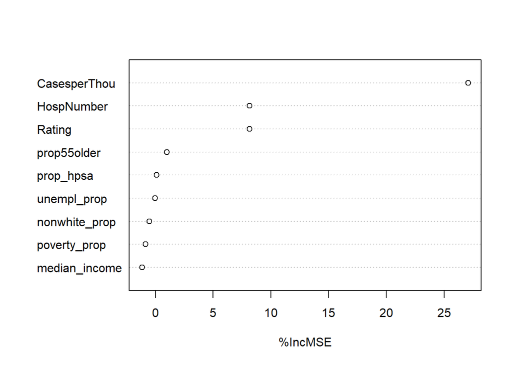

Figure 2: Importance plot of all predictors in the random forest model.

```r
model_RF <- randomForest(DeathsperThou ~ Rating*CasesperThou + prop_hpsa + nonwhite_prop + median_income + unempl_prop + poverty_prop + Rating*prop55older + Rating*HospNumber, data = train, importance = TRUE, mtry = 7, ntree = 398)
varImpPlot(model_RF, main = "", type = 1)
```

**Full model logistic**

```r
set.seed(123)
log_full <- glm(as.factor(hpsa_status) ~., data = hpsa_train,
                family = "binomial")

tidy(log_full)
```

Table 4: Full Logistic Regression Model

```
# A tibble: 13 × 5
   term                                     estimate std.error statistic p.value
   <chr>                                       <dbl>     <dbl>     <dbl>   <dbl>
 1 (Intercept)                               2.55e+1   7.30e+3   3.50e-3 0.997
 2 metropolitan_indicatorMetropolitan       -1.02e+0   7.49e+3  -1.36e-4 1.00
 3 metropolitan_indicatorNon-Metropolitan   -7.54e-1   7.55e+3  -9.98e-5 1.00
 4 metropolitan_indicatorUnknown            -2.09e+1   7.30e+3  -2.87e-3 0.998
 5 designation_typeHigh Needs Geographic H… -3.71e-1   5.27e-1  -7.05e-1 0.481
 6 designation_typeHPSA Population          -2.18e+0   1.10e+0  -1.98e+0 0.0474
 7 hpsa_score                               -1.81e-1   5.90e-2  -3.08e+0 0.00209
 8 hpsa_designation_population               1.93e-6   6.64e-6   2.91e-1 0.771
 9 u_s_mexico_border_county_indicatorY      -8.40e-2   7.90e-1  -1.06e-1 0.915
10 rural_statuspartially_rural               3.48e-2   5.73e+3   6.07e-6 1.00
11 rural_statusrural                         7.71e-2   4.16e-1   1.85e-1 0.853
12 rural_statusunknown                      -1.81e+0   8.54e-1  -2.12e+0 0.0343
13 hpsa_population_typenative_american      -3.20e+0   1.07e+0  -2.99e+0 0.00277
```

**Reduced model**

```r
set.seed(123)
log_reduced <- glm(as.factor(hpsa_status) ~ designation_type + hpsa_score +
                     rural_status + hpsa_population_type, data = hpsa_train,
                   family = "binomial")

summary(log_reduced)
```

Table 5: Reduced Logistic Regression Model

```
Call:
glm(formula = as.factor(hpsa_status) ~ designation_type + hpsa_score +
    rural_status + hpsa_population_type, family = "binomial",
    data = hpsa_train)

Coefficients:
                                            Estimate Std. Error z value
(Intercept)                                  6.25862    0.93204   6.715
designation_typeHigh Needs Geographic HPSA  -0.64684    0.45256  -1.429
designation_typeHPSA Population             -1.46585    0.60276  -2.432
hpsa_score                                  -0.31939    0.03875  -8.242
rural_statuspartially_rural                 13.09281  759.83452   0.017
rural_statusrural                           -0.05037    0.33005  -0.153
rural_statusunknown                         -2.66319    0.83559  -3.187
hpsa_population_typenative_american         -2.41549    0.59263  -4.076
                                           Pr(>|z|)
(Intercept)                                1.88e-11 ***
designation_typeHigh Needs Geographic HPSA  0.15293
designation_typeHPSA Population             0.01502 *
hpsa_score                                  < 2e-16 ***
rural_statuspartially_rural                 0.98625
rural_statusrural                           0.87871
rural_statusunknown                         0.00144 **
hpsa_population_typenative_american        4.58e-05 ***
---
Signif. codes:  0 '***' 0.001 '**' 0.01 '*' 0.05 '.' 0.1 ' ' 1

(Dispersion parameter for binomial family taken to be 1)

    Null deviance: 453.02  on 351  degrees of freedom
Residual deviance: 249.95  on 344  degrees of freedom
AIC: 265.95

Number of Fisher Scoring iterations: 15
```

```r
# Reduced model
# Predictions
preds_reduced <- predict(log_reduced, newdata = hpsa_test, type = "response")

# Convert to classification prediction
Yhat_reduced <-  ifelse(preds_reduced >= 0.5, "Withdrawn", "Designated")

# confusion matrix
confm_reduced <- table(Yhat_reduced, hpsa_test$hpsa_status)

# Correct classification prediction rate
accuracy_reduced <- sum(confm_reduced[1], confm_reduced[4])/sum(confm_reduced)

# test error rate
error_reduced <- mean(Yhat_reduced != hpsa_test$hpsa_status)
```

```r
# Full model
# Predictions
preds <- predict(log_full, newdata = hpsa_test, type = "response")

# Convert to classification prediction
Yhat <-  ifelse(preds >= 0.5, "Withdrawn", "Designated")

# confusion matrix
confm <- table(Yhat, hpsa_test$hpsa_status)

# Correct classification prediction rate
accuracy <- sum(confm[1], confm[4])/sum(confm)

# test error rate
error_full <- mean(Yhat != hpsa_test$hpsa_status)
```

```r
set.seed(123)

# Loss function
Lossfn <- function(Y, p) {
  mean(1 * (Y == 1 & p <= .50) | (1 * (Y == 0 & p > .50)),
       na.rm = TRUE)
}

# Convert response to numeric 0's and 1's
hpsa$Y <- as.numeric(as.factor(hpsa$hpsa_status)) - 1
```

```r
library(boot)
set.seed(123)

## Prediction error rate
# K = 10

# KFold Reduced
Kfold_reduced <- cv.glm(hpsa, log_reduced, cost = Lossfn, K=10)$delta


# Full Model
Kfold_full <- cv.glm(hpsa, log_full, cost = Lossfn, K=10)$delta
```

**Compare models Full and reduced logistic regression models**

```r
anov <- anova(log_reduced, log_full, test = "Chisq")
anov
```

Table 6: Model comparison

```
Analysis of Deviance Table

Model 1: as.factor(hpsa_status) ~ designation_type + hpsa_score + rural_status +
    hpsa_population_type
Model 2: as.factor(hpsa_status) ~ metropolitan_indicator + designation_type +
    hpsa_score + hpsa_designation_population + u_s_mexico_border_county_indicator +
    rural_status + hpsa_population_type
  Resid. Df Resid. Dev Df Deviance  Pr(>Chi)
1       344     249.95
2       339     191.42  5   58.529 2.446e-11 ***
---
Signif. codes:  0 '***' 0.001 '**' 0.01 '*' 0.05 '.' 0.1 ' ' 1
```

**Un-pruned decision Tree**

```r
#| tbl-cap: "Unpruned model output"
#| label: tbl-unpruned-result
#| echo: false

set.seed(123)
summary(tr)
```

```
Classification tree:
tree(formula = as.factor(hpsa_status) ~ ., data = train)
Variables actually used in tree construction:
[1] "hpsa_score"                  "hpsa_designation_population"
Number of terminal nodes:  12
Residual mean deviance:  0.6527 = 161.9 / 248
Misclassification error rate: 0.1385 = 36 / 260
```

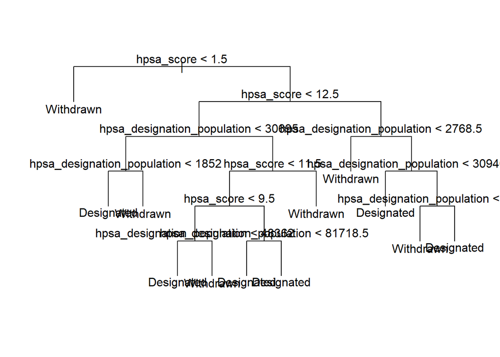

Figure 3: Decision tree from unpruned model with 12 nodes

**Pruned Tree**

```
$size
[1] 12 11 10  8  3  2  1

$dev
[1]  69  69  63  61  62  77 100

$k
[1] -Inf  0.0  1.0  1.5  3.0 13.0 25.0

$method
[1] "misclass"

attr(,"class")
[1] "prune"         "tree.sequence"
```

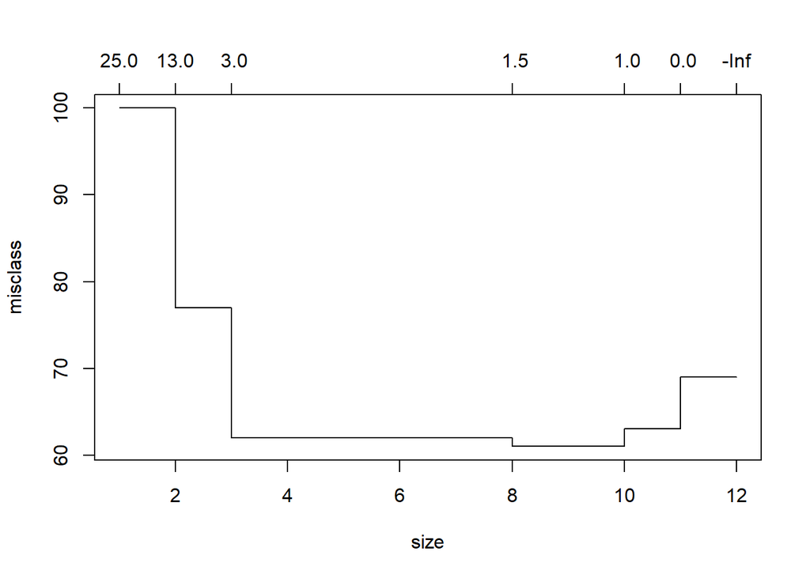

```r
plot(cv)
```

Tree size 8 corresponds to the lowest cross-validated classification error rate with the fewest nodes.

Table 7: Pruned model output

```
Classification tree:
snip.tree(tree = tr, nodes = c(53L, 12L, 15L))
Variables actually used in tree construction:
[1] "hpsa_score"                  "hpsa_designation_population"
Number of terminal nodes:  8
Residual mean deviance:  0.7143 = 180 / 252
Misclassification error rate: 0.1538 = 40 / 260
```

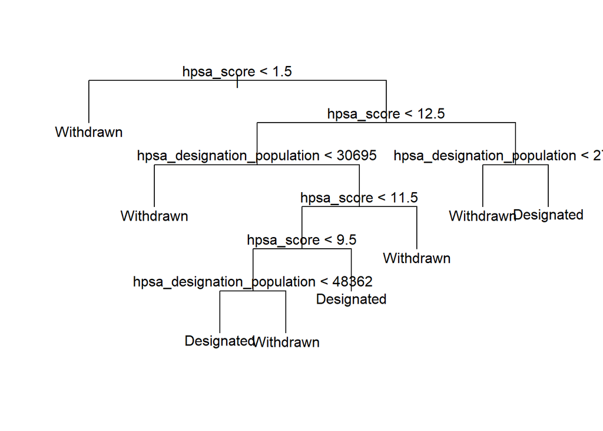

Figure 5: Decision tree from pruned model with 8 nodes

**Initial boosting model**

```r
#| echo: false
#| tbl-cap: "Initial boosting model ouput"
#| label: tbl-initialboosting

set.seed(123)
boosth
```

```
gbm(formula = hpsa_status ~ ., distribution = "Bernoulli", data = train_b,
    n.trees = 3000)
A gradient boosted model with Bernoulli loss function.
 3000 iterations were performed.
There were 7 predictors of which 7 had non-zero influence.
```

```
                                                                  var
metropolitan_indicator                         metropolitan_indicator
hpsa_score                                                 hpsa_score
hpsa_population_type                             hpsa_population_type
hpsa_designation_population               hpsa_designation_population
designation_type                                     designation_type
rural_status                                             rural_status
u_s_mexico_border_county_indicator u_s_mexico_border_county_indicator
                                        rel_inf
metropolitan_indicator             76.228639138
hpsa_score                         18.837306324
hpsa_population_type                2.689845808
hpsa_designation_population         1.149605087
designation_type                    0.944460900
rural_status                        0.142845378
u_s_mexico_border_county_indicator  0.007297366
```

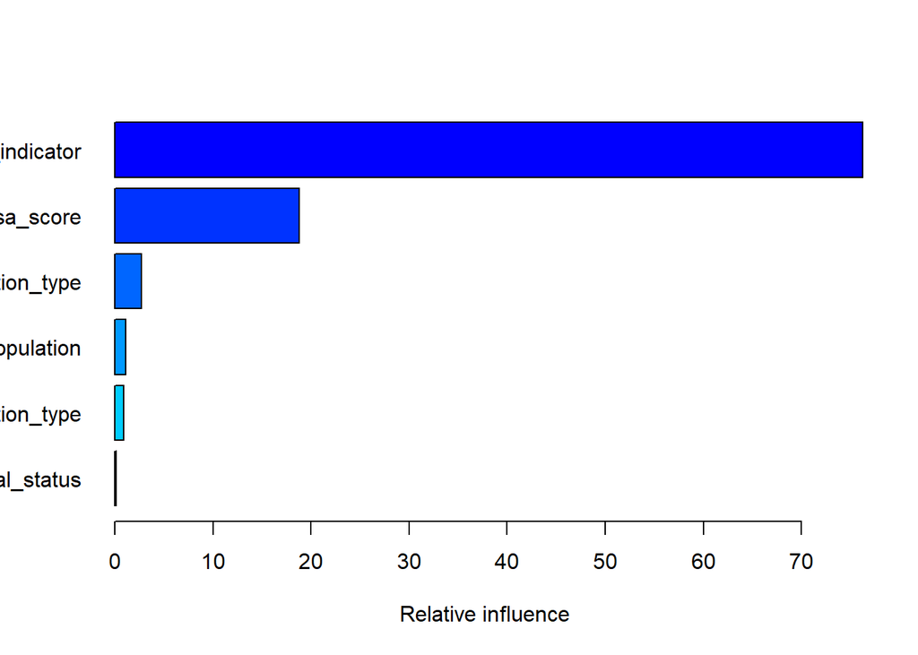

Figure 6: Top 6 important variables for initial boosting model

**Using Shrinkage parameter**

```r
#| echo: false
#| tbl-cap: "boosting model with shrinkage parameter ouput"
#| label: tbl-boostingshrinkage

set.seed(123)
#adjust the shrinkage parameter
boosth_shrink
```

```
gbm(formula = hpsa_status ~ ., distribution = "Bernoulli", data = train_b,
    n.trees = 5000, shrinkage = 0.001)
A gradient boosted model with Bernoulli loss function.
 5000 iterations were performed.
There were 7 predictors of which 7 had non-zero influence.
```

```
                                                                  var
metropolitan_indicator                         metropolitan_indicator
hpsa_score                                                 hpsa_score
hpsa_population_type                             hpsa_population_type
hpsa_designation_population               hpsa_designation_population
designation_type                                     designation_type
rural_status                                             rural_status
u_s_mexico_border_county_indicator u_s_mexico_border_county_indicator
                                       rel_inf
metropolitan_indicator             71.37882009
hpsa_score                         19.27404814
hpsa_population_type                4.00518646
hpsa_designation_population         3.41247481
designation_type                    1.19690539
rural_status                        0.70524554
u_s_mexico_border_county_indicator  0.02731957
```

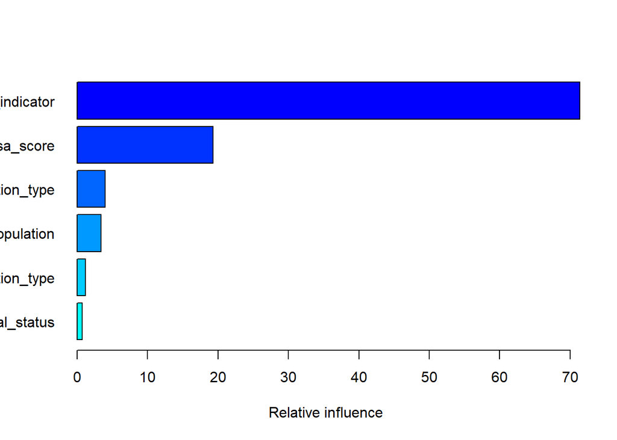

Figure 7: Top 6 important variables for boosting with shrinkage model

```r
summary(boosth_shrink, cBars = 6)
```

**Using Cross Validation with shrinkage parameter**

```r
#| echo: false
#| tbl-cap: "Cross validated boosting model with shrinkage parameter"
#| label: tbl-boostingshrinkage-cv

set.seed(123)
boosth_cv
```

```
gbm(formula = hpsa_status ~ ., distribution = "Bernoulli", data = train_b,
    n.trees = 3000, shrinkage = 0.001, cv.folds = 10)
A gradient boosted model with Bernoulli loss function.
 3000 iterations were performed.
The best cross-validation iteration was 3000.
There were 7 predictors of which 7 had non-zero influence.

Cross-validation confusion matrix:
   0   1 Pred. Acc.
0 85  15       85.0
1 33 160       82.9

Cross-validation prediction Accuracy = 83.62%
```

[output not shown]

[figure not shown]